# Homework - exercise 1.2

Edyta Pszczółkowska 435022

29 12 2021

Exercise 1.2 Load the data for the credit risk applications. Run necessary preprocessing steps. Train logistic regression, random forest and xgboost models. Compare the models performance for AUC. Are the ML models better or worse than logistic regression? Choose a probability of default threshold level for one of the models and justify your selection.

## Data preparation

```r
library(ROCR)
library(randomForest)
library(xgboost)
library(scorecard)

# lets change the LC_TIME option to English
Sys.setlocale("LC_TIME", "English")
```

```
## [1] "English_United States.1252"
```

```r
# setting the working directory
setwd("D:\\Edyta pliki\\DS\\III semestr\\AppFinance\\Lab M. Buczynski\\lab_05_hw\\HW")

#dataset source: https://www.kaggle.com/laotse/credit-risk-dataset

data <- read.csv("credit_risk_dataset.csv", header = TRUE)
```

## Preparing dataset:

As the dataset is so huge, we can afford to delete rows with NAs.

```r
data <- data[complete.cases(data),]
```

Let’s inspect the variables one-by-one and delete outliers/mistaken records:

```r
colnames(data)
```

```
##  [1] "person_age"                 "person_income"
##  [3] "person_home_ownership"      "person_emp_length"
##  [5] "loan_intent"                "loan_grade"
##  [7] "loan_amnt"                  "loan_int_rate"
##  [9] "loan_status"                "loan_percent_income"
## [11] "cb_person_default_on_file"  "cb_person_cred_hist_length"
```

I will start with the dependent variable:

```r
table(data$loan_status)
```

```
##
##     0     1
## 22435  6203
```

The ratio of default cutomers: 21,66% The ratio of non- default cutomers: 78,34%

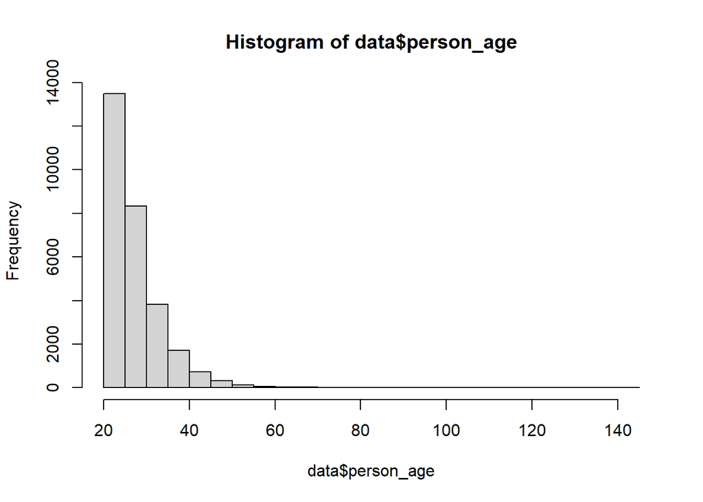

```r
#AGE
hist(data$person_age, breaks = 30)
```

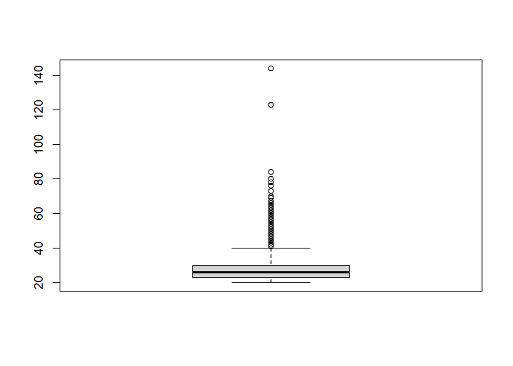

```r
boxplot(data$person_age)
```

Bye bye customers older than 100 years:

```r
data <- data[data$person_age < 100 , ]
```

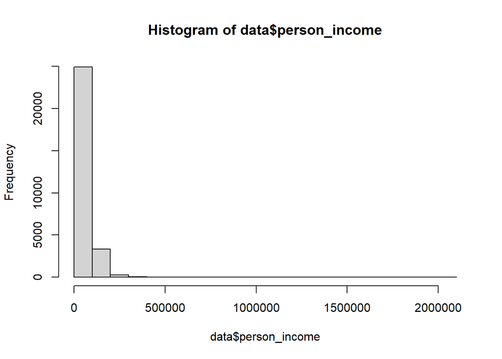

```r
#INCOME
hist(data$person_income)
```

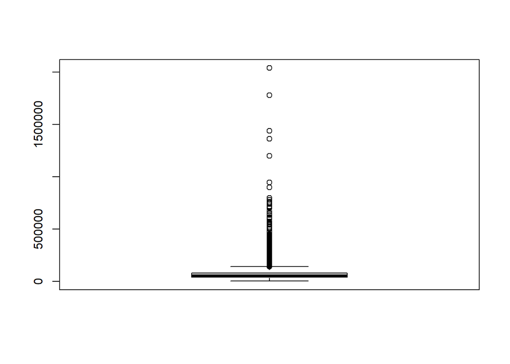

```r
boxplot(data$person_income)
```

To avoid distortion I will exclude customers with income higher than 1.000.000 USD:

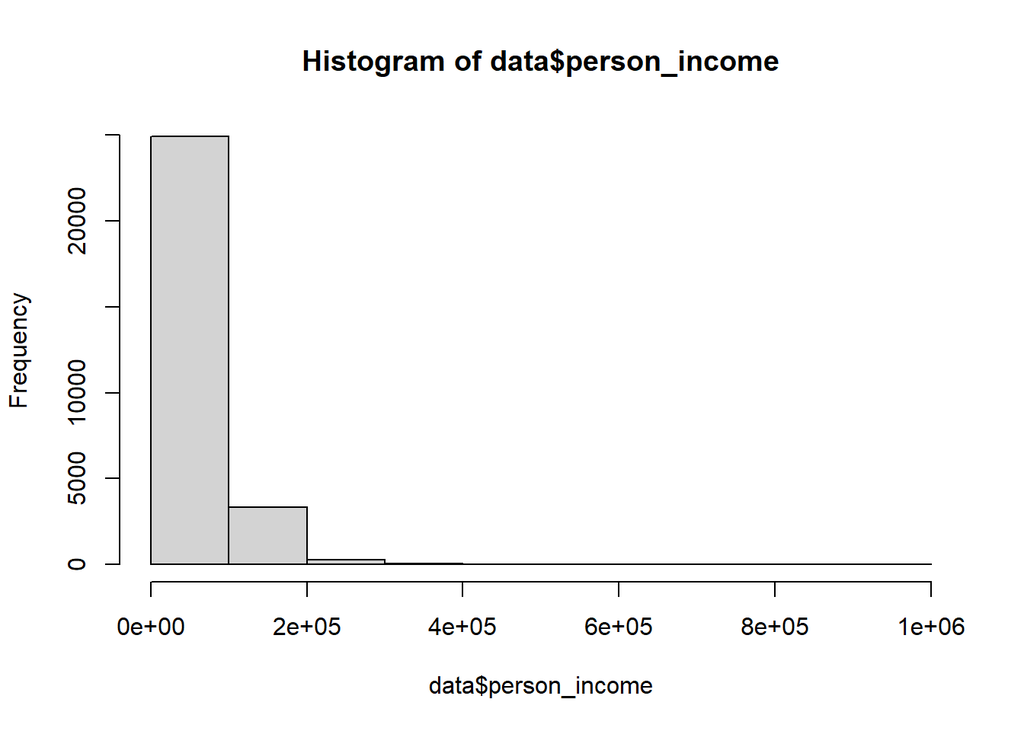

```r
data <- data[data$person_income < 1000000 , ]

hist(data$person_income, breaks = 10, )
```

Let’s bin this variable :

```r
data$person_income <-
  (ifelse(
    data$person_income <= 30000   , '0-30k',
    ifelse( data$person_income <= 60000, '30-60k', '60k+')))



data$person_income <- factor(data$person_income,
                           # levels from lowest to highest
                           levels = c('0-30k', '30-60k', '60k+' ),  ordered = TRUE)

table(data$person_income)
```

```
##
##  0-30k 30-60k   60k+
##   3750  12527  12351
```

Next one rather self-explanatory:

```r
table(data$person_home_ownership)
```

```
##
## MORTGAGE    OTHER      OWN     RENT
##    11796       94     2191    14547
```

```r
data$person_home_ownership <- as.factor(data$person_home_ownership)
```

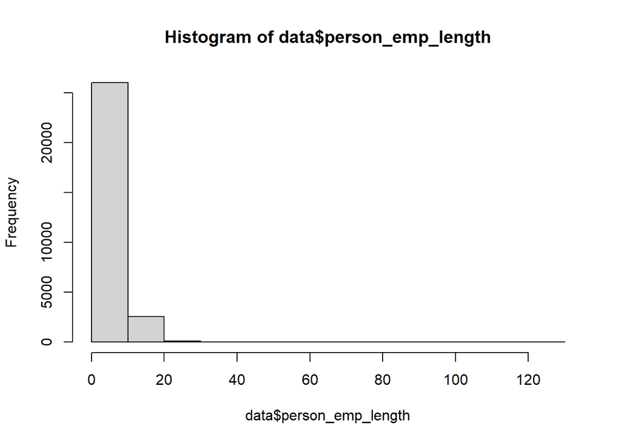

```r
hist(data$person_emp_length)
```

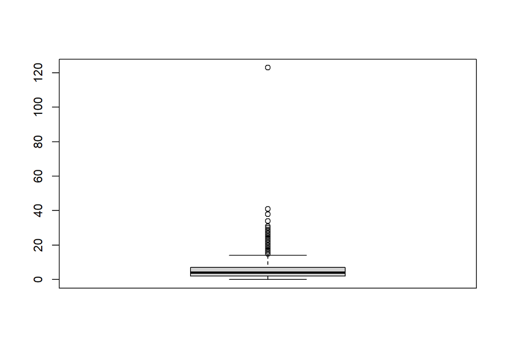

```r
boxplot(data$person_emp_length)
```

What an imagination! Let’s delete the most unbelievable records:

```r
data <- data[data$person_emp_length < 50 , ]
```

```r
table(data$loan_intent)
```

```
##
## DEBTCONSOLIDATION         EDUCATION   HOMEIMPROVEMENT           MEDICAL
##              4564              5701              3198              5292
##          PERSONAL           VENTURE
##              4875              4996
```

```r
data$loan_intent <- as.factor(data$loan_intent)
```

```r
table(data$loan_grade)
```

```
##
##    A    B    C    D    E    F    G
## 9397 9149 5695 3247  870  209   59
```

let’s put E,F and G into one group:

```r
data$loan_grade[data$loan_grade == "E"  ] <- "E,F,G"
data$loan_grade[data$loan_grade == "F"  ] <- "E,F,G"
data$loan_grade[data$loan_grade == "G"  ] <- "E,F,G"

data$loan_grade <- factor(data$loan_grade,
                           # levels from lowest to highest
                           levels = c("E,F,G", 'D', 'C', 'B', 'A' ),  ordered = TRUE)

table(data$loan_grade)
```

```
##
## E,F,G     D     C     B     A
##  1138  3247  5695  9149  9397
```

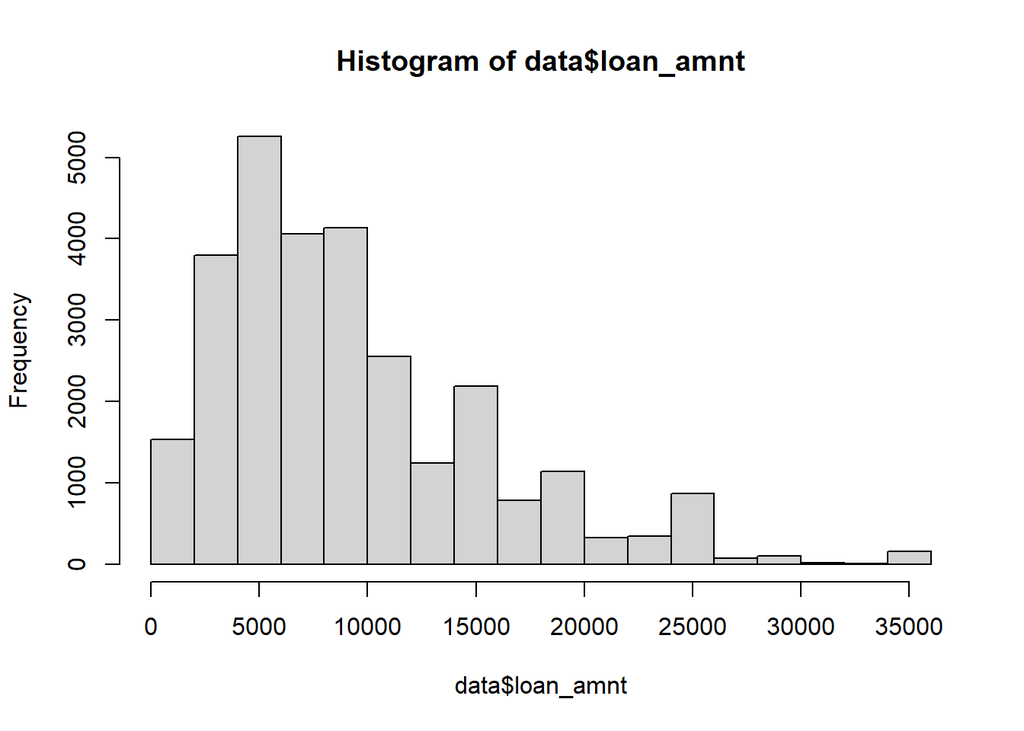

```r
hist(data$loan_amnt)
```

Let’s bin this varibale:

```r
data$loan_amnt <-
  as.factor(ifelse(
    data$loan_amnt <= 10000, '0-10k',
    ifelse(data$loan_amnt <= 25000, '10-25k', '25k+')
  ))


data$loan_amnt <- factor(data$loan_amnt,
                           # levels from lowest to highest
                           levels = c('0-10k', '10-25k', '25k+' ),  ordered = TRUE)


table(data$loan_amnt)
```

```
##
##  0-10k 10-25k   25k+
##  18787   9452    387
```

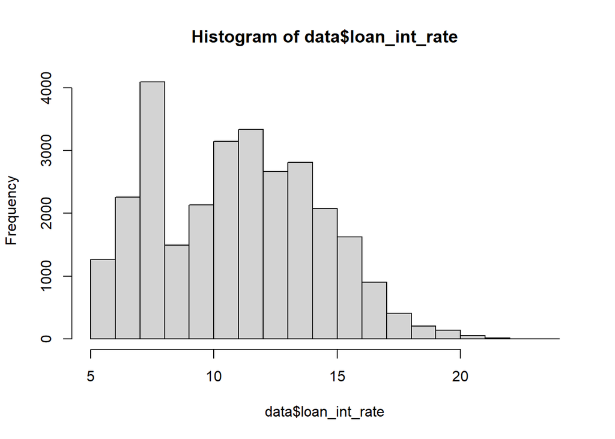

```r
hist(data$loan_int_rate)
```

Let’s bin this varibale:

```r
data$loan_int_rate <-
  as.factor(ifelse(
    data$loan_int_rate <= 10, 'low',
    ifelse(data$loan_int_rate <= 15, 'medium', 'high')
  ))


data$loan_int_rate <- factor(data$loan_int_rate,
                           # levels from lowest to highest
                           levels = c("low", 'medium', 'high'  ),  ordered = TRUE)

table(data$loan_int_rate)
```

```
##
##    low medium   high
##  11240  14032   3354
```

The next variable tells us what is the ratio of the loan amount to the customer’s income (derived from dividing loan amount by customer’s income)

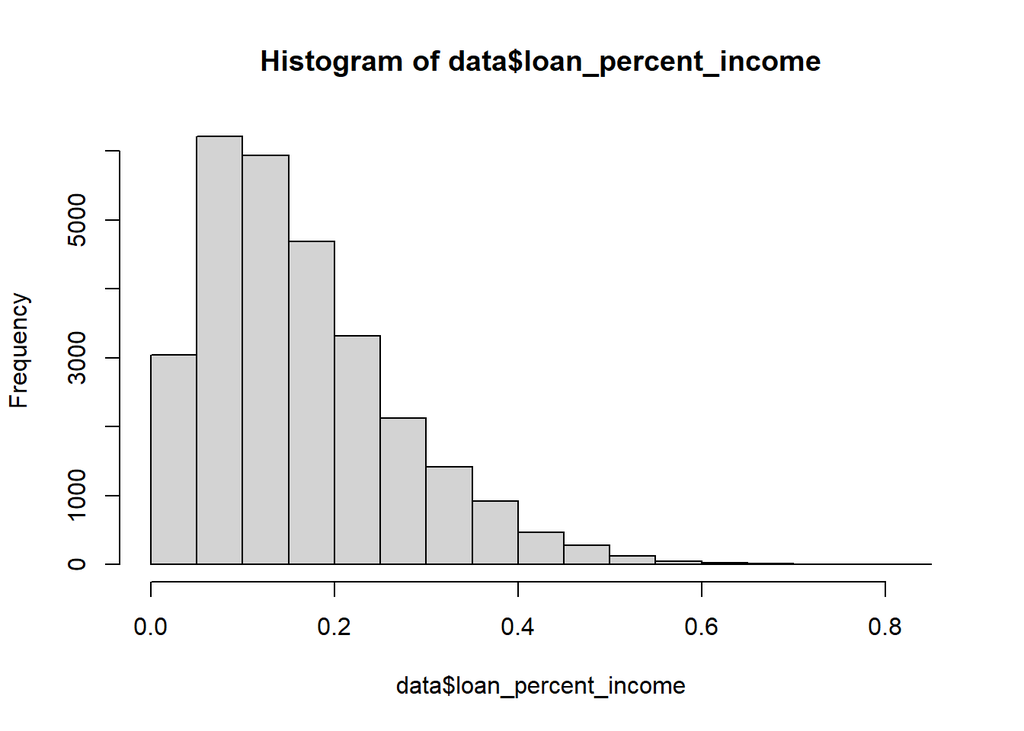

```r
hist(data$loan_percent_income)
```

Next one - historical default

```r
table(data$cb_person_default_on_file)
```

```
##
##     N     Y
## 23525  5101
```

```r
data$cb_person_default_on_file <- as.factor(data$cb_person_default_on_file)
```

The last but not least - Credit history length [years]

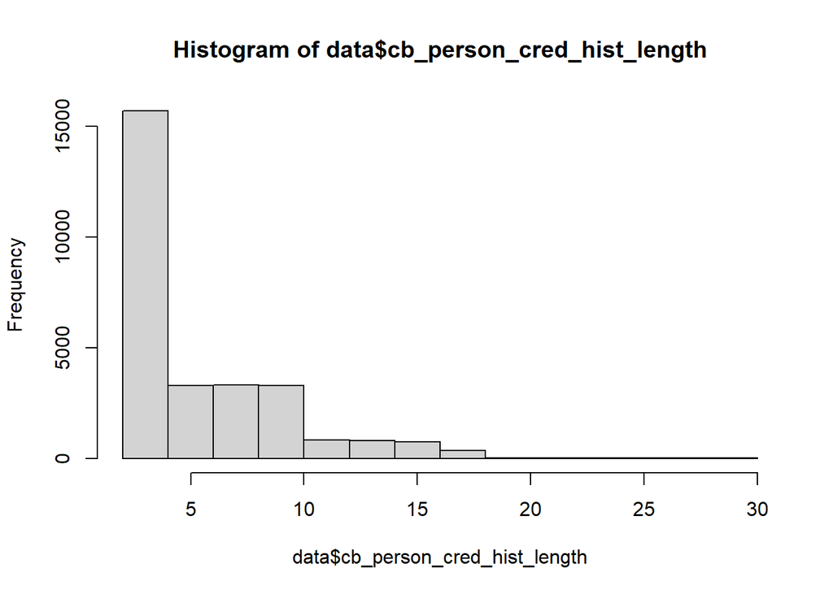

```r
hist(data$cb_person_cred_hist_length )
```

### Models

Division into train and test datasets:

```r
set.seed(123456)
d = sort(sample(nrow(data), nrow(data) * .6))
train <- data[d, ]
test <- data[-d, ]
```

## Logistic regression

the simplest model, will be used as a benchmark

```r
model_lr <- glm(loan_status ~ ., data = train, family = binomial())
summary(model_lr)
```

```
##
## Call:
## glm(formula = loan_status ~ ., family = binomial(), data = train)
##
## Deviance Residuals:
##     Min       1Q   Median       3Q      Max
## -2.9602  -0.5080  -0.2862  -0.1198   3.1396
##
## Coefficients:
##                             Estimate Std. Error z value Pr(>|z|)
## (Intercept)                -2.302626   0.215015 -10.709  < 2e-16 ***
## person_age                 -0.013514   0.008279  -1.632  0.10262
## person_income.L            -0.813260   0.066067 -12.310  < 2e-16 ***
## person_income.Q             0.209326   0.040408   5.180 2.21e-07 ***
## person_home_ownershipOTHER  0.406034   0.427069   0.951  0.34173
## person_home_ownershipOWN   -1.707632   0.144595 -11.810  < 2e-16 ***
## person_home_ownershipRENT   0.881724   0.056422  15.627  < 2e-16 ***
## person_emp_length          -0.017615   0.006670  -2.641  0.00827 **
## loan_intentEDUCATION       -0.900354   0.080088 -11.242  < 2e-16 ***
## loan_intentHOMEIMPROVEMENT  0.064923   0.088931   0.730  0.46536
## loan_intentMEDICAL         -0.132990   0.075161  -1.769  0.07683 .
## loan_intentPERSONAL        -0.678893   0.081205  -8.360  < 2e-16 ***
## loan_intentVENTURE         -1.131924   0.085742 -13.202  < 2e-16 ***
## loan_grade.L               -2.769720   0.136055 -20.357  < 2e-16 ***
## loan_grade.Q                0.568112   0.092986   6.110 9.99e-10 ***
## loan_grade.C                0.673376   0.062526  10.770  < 2e-16 ***
## loan_grade^4               -0.691699   0.054037 -12.801  < 2e-16 ***
## loan_amnt.L                -0.407036   0.150783  -2.699  0.00694 **
## loan_amnt.Q                 0.030117   0.085173   0.354  0.72364
## loan_int_rate.L             0.224031   0.104958   2.134  0.03280 *
## loan_int_rate.Q            -0.040147   0.060583  -0.663  0.50754
## loan_percent_income         9.800566   0.328761  29.811  < 2e-16 ***
## cb_person_default_on_fileY -0.050640   0.068928  -0.735  0.46253
## cb_person_cred_hist_length  0.008405   0.012506   0.672  0.50155
## ---
## Signif. codes:  0 '***' 0.001 '**' 0.01 '*' 0.05 '.' 0.1 ' ' 1
##
## (Dispersion parameter for binomial family taken to be 1)
##
##     Null deviance: 17813  on 17174  degrees of freedom
## Residual deviance: 11302  on 17151  degrees of freedom
## AIC: 11350
##
## Number of Fisher Scoring iterations: 6
```

The least significant variables are: age and information about customer’s credit history.

Let’s see confusion matrix for training set using typical cut-off point:

```r
# let's see how our model predicts defaulting entities
predict <- predict(model_lr, type = 'response', newdata = train)

table(train$loan_status, predict > 0.5)
```

```
##
##     FALSE  TRUE
##   0 12859   649
##   1  1624  2043
```

The results are not satisfactory, especially the number of the default customers assigned by the model to a non-default group is very high (1624). Banks cannot afford so many mistakes, therefore such a model must be either thoroughly corrected or rejected. This can be done by excluding not significant variables or changing the cut-off point.

The 2nd approach can be checked using ROC curve. Such a plot depicts how does the relation between true positive and false positive ratio changes while changing the cut-off point.

Then area under ROC-curve is measured. The most desired outcome would be one - that would mean that our model fetched all true - positive customers and no false positive ones.

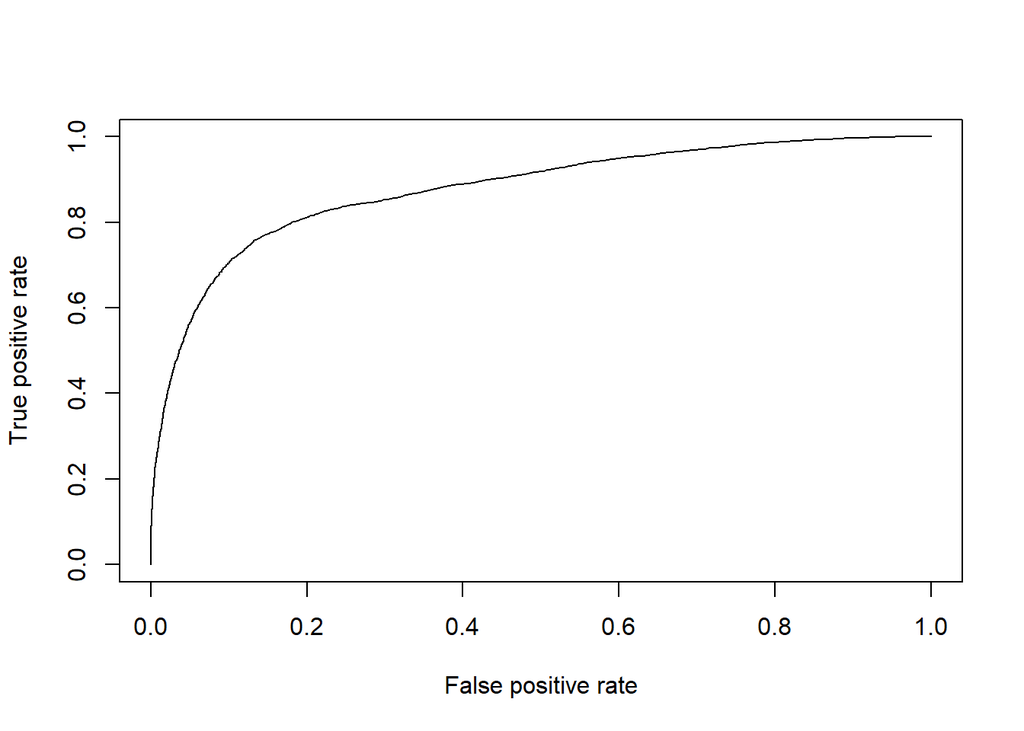

```r
ROCpred <- prediction(predict, train$loan_status)
ROCperf <- performance(ROCpred, 'tpr', 'fpr')
plot(ROCperf)
```

```r
# AUC value
auc <- performance(ROCpred, measure = "auc")
auc <- auc@y.values[[1]]
auc
```

```
## [1] 0.8767559
```

The result is quite satisfactory.

Let’s see how that changes on testing sample:

```r
predict_LR <- predict(model_lr, type = 'response', newdata = test)

# confusion matrix for training set
table(test$loan_status, predict_LR > 0.5)
```

```
##
##     FALSE TRUE
##   0  8472  444
##   1  1157 1378
```

The results on test sample are also disturbing in the same way as train data.

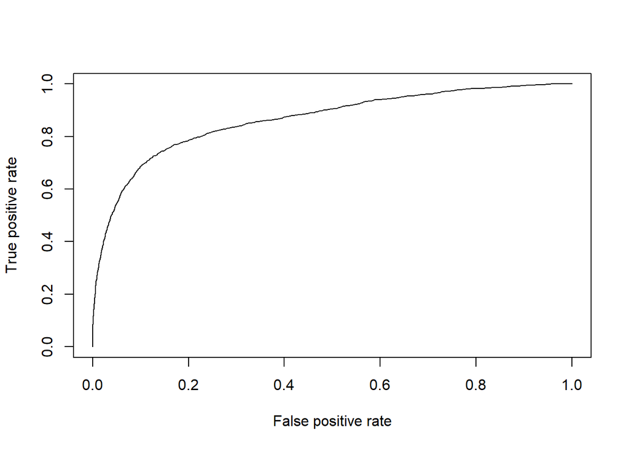

```r
# ROC Curve
ROCpred_t <- prediction(predict_LR, test$loan_status)
ROCperf_t <- performance(ROCpred_t, 'tpr', 'fpr')
plot(ROCperf_t)
```

```r
# AUC value
auc_t <- performance(ROCpred_t, measure = "auc")
auc_t <- auc_t@y.values[[1]]
auc_t
```

```
## [1] 0.8645287
```

```r
all_models_aucs <- c("LR"=auc_t)
```

Conclusion: the model performs almost same for both subsets of data judging by confusion matrix and ROC/AUC measures.

Let’s store the results on test sample to a data frame in order to compare the performance of all the models later.

```r
all_models_aucs <- c("LR"=auc_t)
```

## Random forests

```r
modelrf <- randomForest(loan_status ~ ., data = train, importance = TRUE, ntree = 100)


predict_RF <- predict(modelrf, type = 'response', newdata = test)
table(test$loan_status, predict_RF > 0.5)
```

```
##
##     FALSE TRUE
##   0  8853   63
##   1   915 1620
```

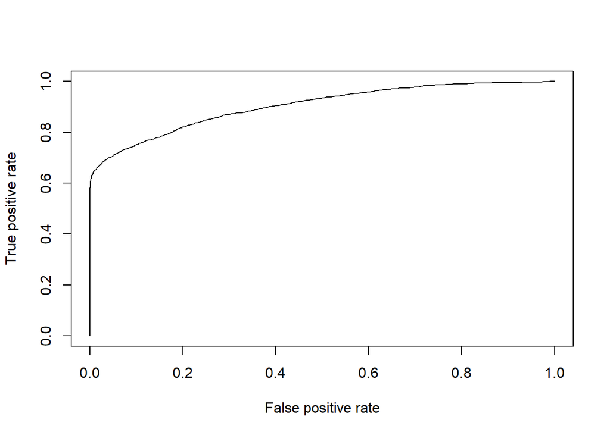

```r
ROCpred_t <- prediction(predict_RF, test$loan_status)
ROCperf_t <- performance(ROCpred_t, 'tpr', 'fpr')
plot(ROCperf_t)
```

```r
# AUC value
auc_t <- performance(ROCpred_t, measure = "auc")
auc_t <- auc_t@y.values[[1]]
auc_t
```

```
## [1] 0.9031319
```

```r
all_models_aucs <- c(all_models_aucs, "RF"=auc_t)
```

Judging by confusion matrix, this model is much much better than logistic regression - the numbers on diagonal are higher than in previous case. Therefore are those off-diagonal lower meaning that there are less false positive and false negative cases.

## XGBoost

Firstly, we have to check if all the proper variables were converted to the factors:

```r
str(data)
```

```
## 'data.frame':    28626 obs. of  12 variables:
##  $ person_age                : int  21 25 23 24 21 26 24 24 21 22 ...
##  $ person_income             : Ord.factor w/ 3 levels "0-30k"<"30-60k"<..: 1 1 3 2 1 3 3 3 1 3 ...
##  $ person_home_ownership     : Factor w/ 4 levels "MORTGAGE","OTHER",..: 3 1 4 4 3 4 4 4 3 4 ...
##  $ person_emp_length         : num  5 1 4 8 2 8 5 8 6 6 ...
##  $ loan_intent               : Factor w/ 6 levels "DEBTCONSOLIDATION",..: 2 4 4 4 6 2 4 5 6 6 ...
##  $ loan_grade                : Ord.factor w/ 5 levels "E,F,G"<"D"<"C"<..: 4 3 3 3 5 4 4 5 2 4 ...
##  $ loan_amnt                 : Ord.factor w/ 3 levels "0-10k"<"10-25k"<..: 1 1 3 3 1 3 3 3 1 3 ...
##  $ loan_int_rate             : Ord.factor w/ 3 levels "low"<"medium"<..: 2 2 3 2 1 2 2 1 2 2 ...
##  $ loan_status               : int  0 1 1 1 1 1 1 1 1 1 ...
##  $ loan_percent_income       : num  0.1 0.57 0.53 0.55 0.25 0.45 0.44 0.42 0.16 0.41 ...
##  $ cb_person_default_on_file : Factor w/ 2 levels "N","Y": 1 1 1 2 1 1 1 1 1 1 ...
##  $ cb_person_cred_hist_length: int  2 3 2 4 2 3 4 2 3 4 ...
```

Yes, they are.

Then we can convert whole training dataset to numeric values

```r
xgb_train <-
  matrix(unlist(lapply(train[,-which(colnames(train) == "loan_status")], as.numeric)), ncol = ncol(train) - 1)



xgb_test <-
  matrix(unlist(lapply(test[,-which(colnames(test) == "loan_status")], as.numeric)), ncol = ncol(test) - 1)
```

Having prepared the data we can run a model:

```r
modelxgb <- xgboost(
  data = xgb_train,
  label = train$loan_status,
  nrounds = 100,
  objective = "binary:logistic"
)
```

```
## [21:36:16] WARNING: amalgamation/../src/learner.cc:1115: Starting in XGBoost 1.3.0, the default evaluation metric used with the objective 'binary:logistic' was changed from 'error' to 'logloss'. Explicitly set eval_metric if you'd like to restore the old behavior.
```

```r
predict_XGB <- predict(modelxgb, type = 'response', newdata = xgb_test)
table(test$loan_status, predict_XGB > 0.5)
```

```
##
##     FALSE TRUE
##   0  8795  121
##   1   875 1660
```

This model gives better predictions for default customers in comparison to RF model - more true positive and less false negative numbers.

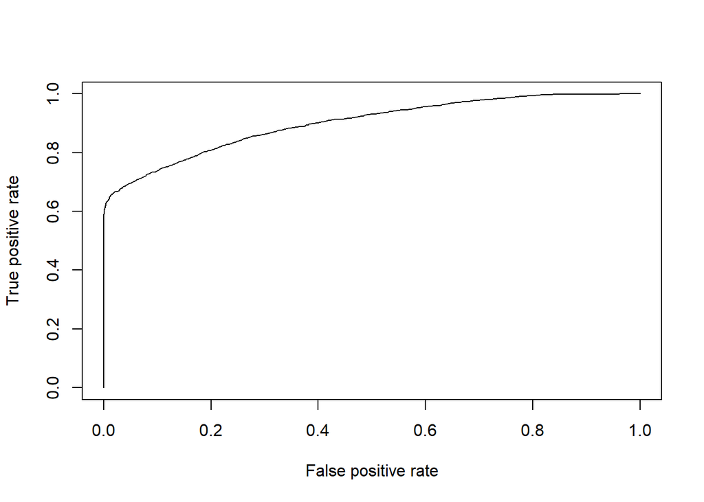

```r
ROCpred_t <- prediction(predict_XGB, test$loan_status)
ROCperf_t <- performance(ROCpred_t, 'tpr', 'fpr')
plot(ROCperf_t)
```

```r
# AUC value
auc_t <- performance(ROCpred_t, measure = "auc")
auc_t <- auc_t@y.values[[1]]
auc_t
```

```
## [1] 0.8999906
```

```r
all_models_aucs <- c(all_models_aucs, "XGB"=auc_t)
```

## Assesment and comparison of the models

And now time to compare all the three models:

```r
all_models_aucs
```

```
##        LR        RF       XGB
## 0.8645287 0.9031319 0.8999906
```

Judging by AUC measure the best one is a random forest algorithm, whereas logistic regression is clearly worse than both XGBoost and RF.

Regarding the last task to do, I will choose the random forest model (as it gave the best AUC outcome) and try to estimate the model choosing the cut off-point, for which the ROC curve is closest to the upper left corner on the plot. Let’s have a look at this plot one more time:

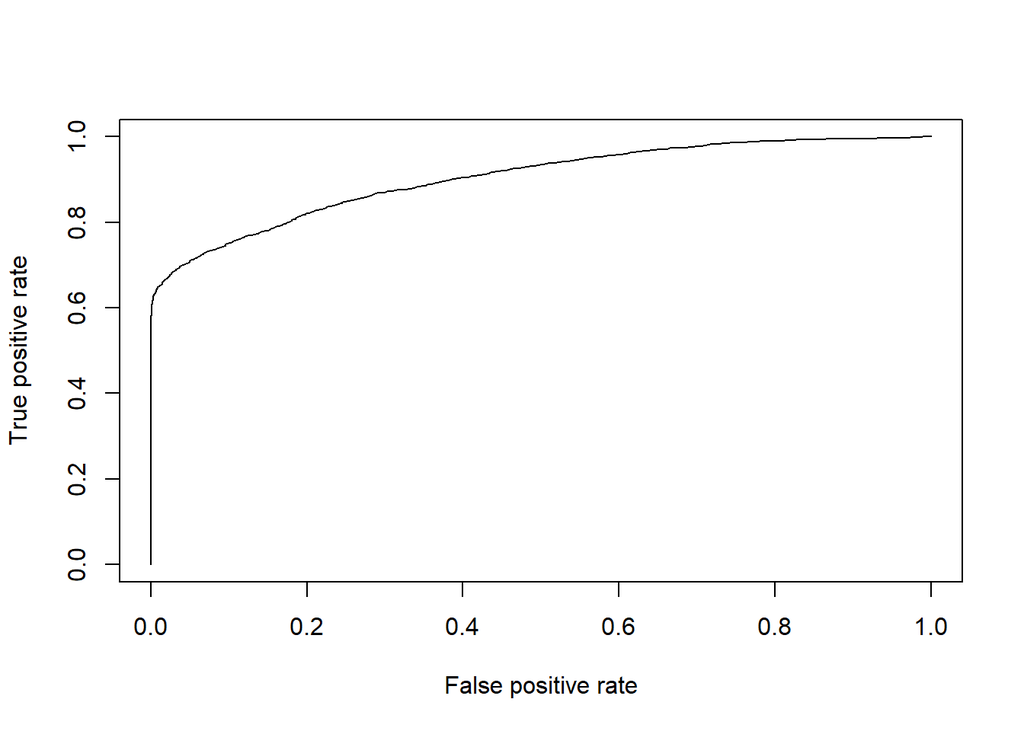

```r
ROCpred_t <- prediction(predict_RF, test$loan_status)
ROCperf_t <- performance(ROCpred_t, 'tpr', 'fpr')
plot(ROCperf_t)
```

I will use the function found on the internet to find the point on the ROC curve, which satisfies the condition mentioned above.

(source: https://www.r-bloggers.com/2014/12/a-small-introduction-to-the-rocr-package/)

```r
opt.cut = function(perf, pred){
    cut.ind = mapply(FUN=function(x, y, p){
        d = (x - 0)^2 + (y-1)^2
        ind = which(d == min(d))
        c(sensitivity = y[[ind]], specificity = 1-x[[ind]],
            cutoff = p[[ind]])
    }, perf@x.values, perf@y.values, pred@cutoffs)
}
print(opt.cut(ROCperf_t, ROCpred_t))
```

```
##                  [,1]
## sensitivity 0.7692308
## specificity 0.8759533
## cutoff      0.2003425
```

```r
table(test$loan_status, predict_RF > 0.2003425)
```

```
##
##     FALSE TRUE
##   0  7810 1106
##   1   585 1950
```